# political_forecaster_without_datageneration

Zsopi

7 March 2016

### In this version I import the dataframe saved in the longer version, so it does not need to rebuild it each time.

## (Machine) Learning about political trouble

### This code implements an estimation of “political trouble” in a given year in a given country my machine learning methods. One country-year is one record.

## Variable definitions and data sources

### “Political trouble” is a binary target variable, defined as 1 if either of the following happening in the given year: coup, attempted coup, self-coup, rebels ousting executive, interregnum periods (as defined by code -77 in the Polity IV database, see [**here**](http://www.systemicpeace.org/inscr/p4manualv2013.pdf)), civil war or violence, ethnic war or violence (otherwise the variable is 0). The civil violence data is described [**here**](http://www.systemicpeace.org/inscr/MEPVcodebook2014.pdf) and the data sources is [**here**](http://www.systemicpeace.org/inscr/MEPV2014.xls). The estimate uses the “CIVTOT” variable, but only with an intensity code of at least 3 (on a 0 to 10 scale). This is to exclude long running, often low intensity cases like ethnic strife in China or Thailand that is still ongoing. The definition of “political trouble” includes only domestic events and excludes cases of external wars. The source of political variables is the [**Center for Systemic Peace**](http://www.systemicpeace.org/inscrdata.html).

### Features (or independent variables) are:

- **ln_gdp_pc**: The natural log of) GDP per capita at purchasing power in 2011 USA dollars. Source: [**IMF**](https://www.imf.org/external/pubs/ft/weo/2015/02/weodata/index.aspx) World Economic Outlook Database or the [**Maddison Project**](http://www.ggdc.net/maddison/maddison-project/home.htm).
- **gdp_pc_grth_lgd**:Lagged GDP growth rate 5 years up to the year prior to the year examined, % annualized (this is to exclude reverse causation). Source: own calculations from above sources.
- **youth_r**: Ratio of “young” population in the adult population. Source: own calculation based on [**UN demographic data**](http://esa.un.org/unpd/wpp/Download/Standard/ASCII/). For definition of “young” see below – this was the result of a kind of a grid search, final result is 17-24 years old.
- **young_pop_grth**: Growth rate of young population, % per annum. Source: same as above.
- **total_pop_grth**: Growth rate of total population, % per annum. Source: same as above.
- **polity2**: Political system variable. Denotes how authoritarian or democratic is in the country in the given year. originally on a scale of -10 to +10, normalized to 1 to 21. Source: Polity IV: Regime Authority Characteristics and Transitions Datasets from the [**Center for Systemic Peace**](http://www.systemicpeace.org/inscrdata.html).
- **resdummy**: Dummy variable for resource economies (“resdummy”). Takes values of 1 if resource rents where resource rent minus “forest rent” is larger than 20% of GDP in 2013 or latest available, otherwise 0. Source: [**World Bank**](http://data.worldbank.org/indicator/NY.GDP.TOTL.RT.ZS).
- **polity_youthr**: Youth ratio and polity2 interaction terms: the product of the two variables above.
- **gdp_youthr**: Youth ratio and GDP per capita interaction terms: the product of the two variables above.

In the following I collect the necessary variables and construct a unified database, unifying country codes and fixing some bugs in the in-built R functions (like the missing data for Turkey in the Maddsion package). This is a boring part and the code is not shown here (but executed).

The following packages need to be installed (not included in the code as it could mess up execution)

install.packages (“readr”)

install.packages (“dplyr”)

install.packages (“ggplot2”)

install.packages (“xlsx”)

install.packages(“tidyr”)

install.packages(“countrycode”)

install.packages(“data.table”)

install.packages(“pwt8”)

install.packages(“WDI”)

install.packages(“maddison”)

install.packages(“openxlsx”)

install.packages(“readxl”)

install.packages(“h2o”)

install.packages(“pander”)

# Loading saved dataframe

[output not shown]

```
## IP Address: 127.0.0.1
## Port      : 54321
## Session ID: _sid_959d8bc8290bc7731341f78c2e84b45
## Key Count : 0
```

## Some further exploratory data, demographics and xy plots

## Hints of non-linearities

**youth_r**

```
##    Min. 1st Qu.  Median    Mean 3rd Qu.    Max.    NA's
##   0.083   0.190   0.256   0.239   0.287   0.394    3283
```

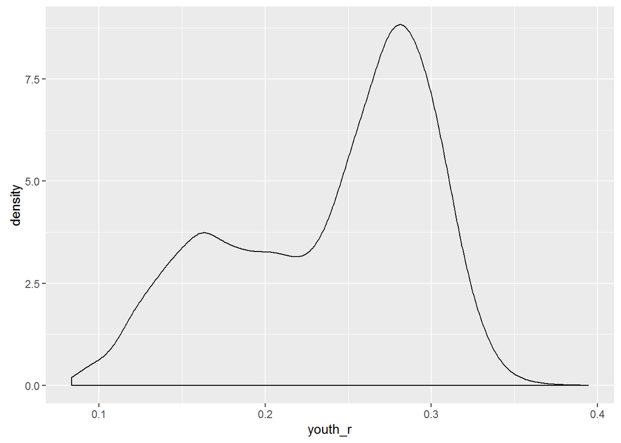

**young_pop_grth**

```
##    Min. 1st Qu.  Median    Mean 3rd Qu.    Max.    NA's
##  -0.150   0.001   0.018   0.016   0.031   0.540    3482
```

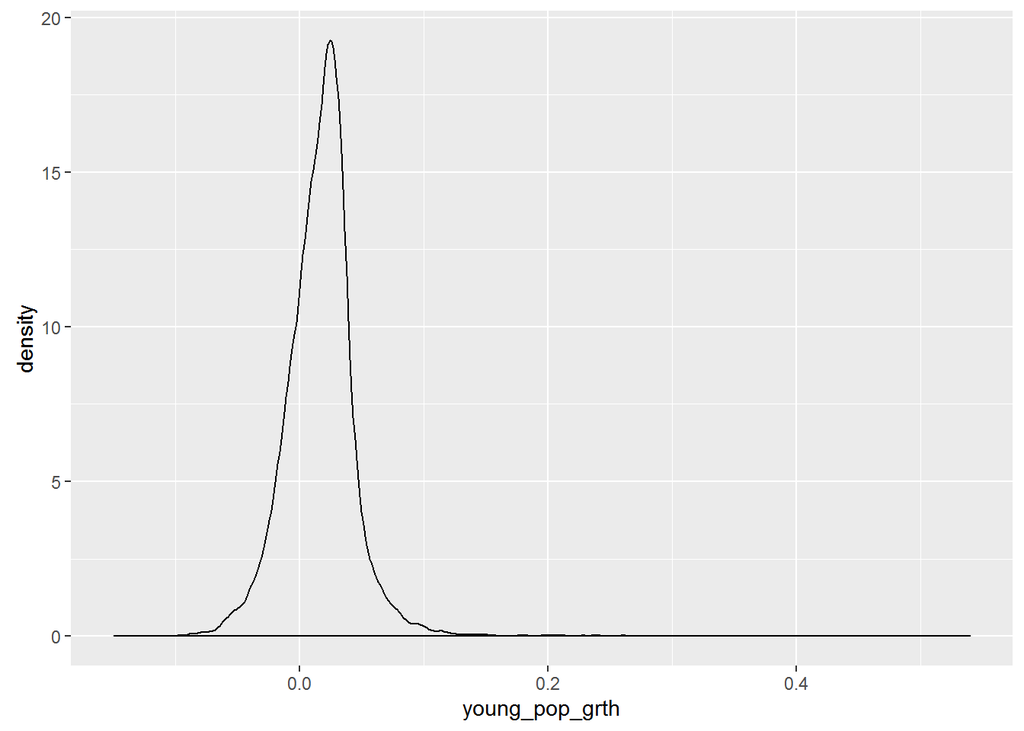

**youth_r and political trouble**

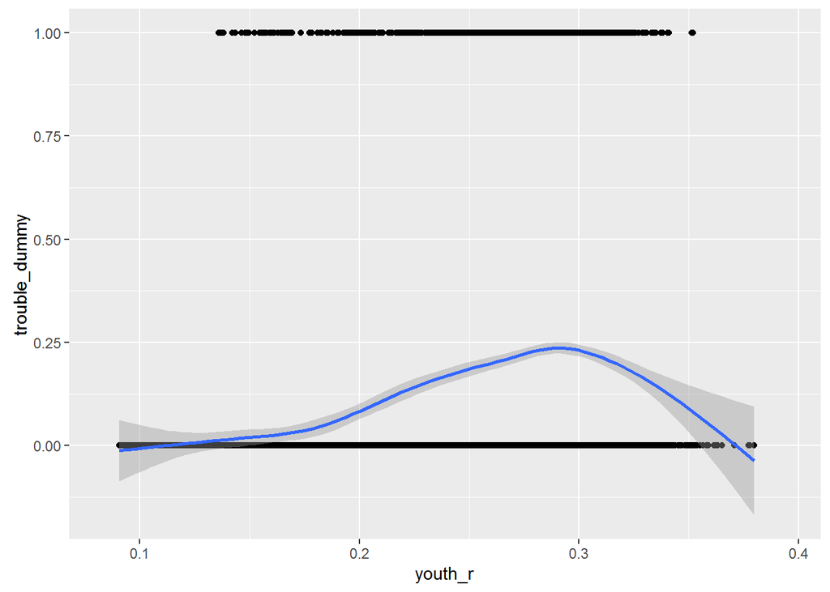

**ln_gdp_pc and political trouble**

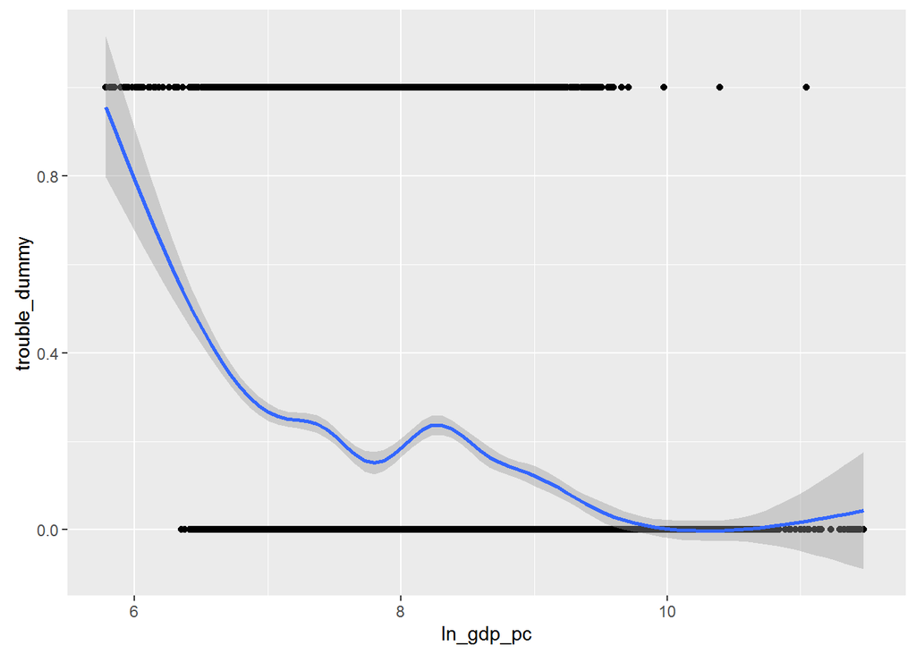

**polity (democracy) and political trouble**

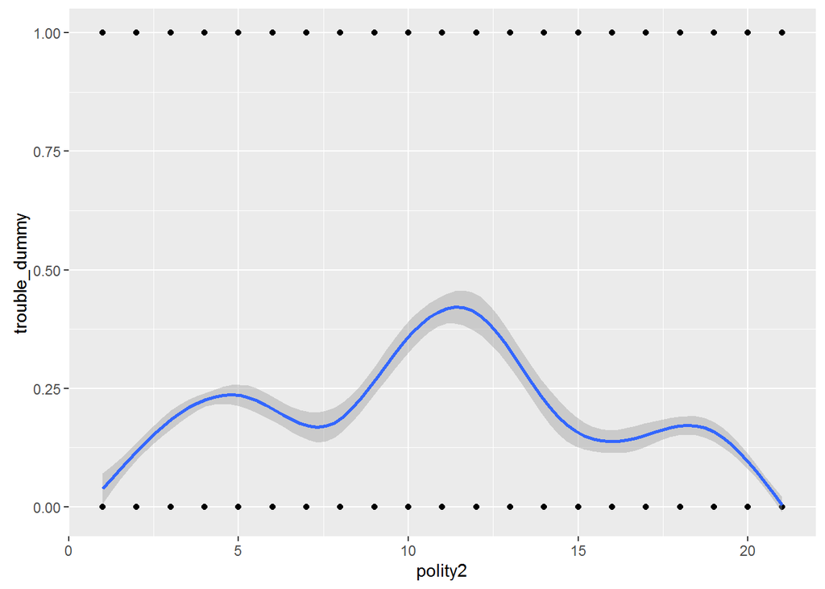

## Grid search

In the following I will show the code for grid searc, but for brevity I will only execute the final models

```r
#gbm grid-search
system.time({
        gbm_gs <- h2o.grid("gbm",
                           x = setdiff(names(ml_data), 'trouble_dummy'),
                           y = 'trouble_dummy',
                        training_frame = h2o_ml_data,
                        nfolds=5,
                        hyper_params = list(ntrees = 500,
                                            max_depth = c(5,10,20,50),
                                            learn_rate = c(0.01,0.1,0.001),
                                            nbins = 200),
                        stopping_rounds = 5, stopping_tolerance = 1e-3)
})

gbm_gs

do.call(rbind, lapply(gbm_gs@model_ids, function(m_id) {
        mm <- h2o.getModel(m_id)
        hyper_params <- mm@allparameters
        data.frame(m_id = m_id,
                   auc = h2o.auc(mm, train=FALSE, xval = TRUE),
                   max_depth = hyper_params$max_depth,
                   learn_rate = hyper_params$learn_rate )
})) %>% arrange(desc(auc))

#second round, finetuning max_depth
system.time({
        gbm_gs <- h2o.grid("gbm",
                           x = setdiff(names(ml_data), 'trouble_dummy'),
                           y = 'trouble_dummy',
                           training_frame = h2o_ml_data,
                           nfolds=5,
                           hyper_params = list(ntrees = 500,
                                               max_depth = c(20,30,40,50),
                                               learn_rate = 0.01),
                           stopping_rounds = 5, stopping_tolerance = 1e-3)
})

gbm_gs

do.call(rbind, lapply(gbm_gs@model_ids, function(m_id) {
        mm <- h2o.getModel(m_id)
        hyper_params <- mm@allparameters
        data.frame(m_id = m_id,
                   auc = h2o.auc(mm, train=FALSE, xval = TRUE),
                   max_depth = hyper_params$max_depth,
                   learn_rate = hyper_params$learn_rate )
})) %>% arrange(desc(auc))

#random forest grid search
system.time({
        rf_gs <- h2o.grid("randomForest",
                           x = setdiff(names(ml_data), 'trouble_dummy'),
                           y = 'trouble_dummy',
                           training_frame = h2o_ml_data,
                           nfolds=5,
                           hyper_params = list(ntrees = c(20,50,500),
                                               max_depth = c(20,30,40,50)),
                          stopping_rounds = 5,
                          stopping_tolerance = 1e-3)
})

rf_gs

do.call(rbind, lapply(rf_gs@model_ids, function(m_id) {
        mm <- h2o.getModel(m_id)
        hyper_params <- mm@allparameters
        data.frame(m_id = m_id,
                   auc = h2o.auc(mm, train=FALSE, xval = TRUE),
                   max_depth = hyper_params$max_depth,
                   ntrees = hyper_params$ntrees )
})) %>% arrange(desc(auc))
```

## Estimating final models

I use 5 folds cross validation in each case (GBM, RandomForest, DeepLearning)

```r
#estimating final models
set.seed(42)

#gbm_final
ml.gbm_final <- h2o.gbm(
        x = setdiff(names(ml_data), 'trouble_dummy'),
        y = 'trouble_dummy',
        training_frame = 'h2o_ml_data',
        nfolds=5,
        ntrees = 500,
        max_depth = 20,
        learn_rate = 0.01,
        stopping_rounds = 5,
        stopping_tolerance = 1e-3,
        model_id = 'ml_gbm_final')
```

```r
ml.gbm_final
```

```
## Model Details:
## ==============
##
## H2OBinomialModel: gbm
## Model ID:  ml_gbm_final
## Model Summary:
##   number_of_trees model_size_in_bytes min_depth max_depth mean_depth
## 1             500             2867194        20        20   20.00000
##   min_leaves max_leaves mean_leaves
## 1        283        623   489.63600
##
##
## H2OBinomialMetrics: gbm
## ** Reported on training data. **
##
## MSE:  0.005697202
## R^2:  0.9565686
## LogLoss:  0.04149525
## AUC:  0.9995838
## Gini:  0.9991676
##
## Confusion Matrix for F1-optimal threshold:
##           0    1    Error     Rate
## 0      7496    5 0.000667  =5/7501
## 1         3 1376 0.002175  =3/1379
## Totals 7499 1381 0.000901  =8/8880
##
## Maximum Metrics: Maximum metrics at their respective thresholds
##                       metric threshold    value idx
## 1                     max f1  0.414861 0.997101 197
## 2                     max f2  0.414861 0.997535 197
## 3               max f0point5  0.483014 0.997099 195
## 4               max accuracy  0.483014 0.999099 195
## 5              max precision  0.991558 1.000000   0
## 6           max absolute_MCC  0.414861 0.996568 197
## 7 max min_per_class_accuracy  0.414861 0.997825 197
##
##
## H2OBinomialMetrics: gbm
## ** Reported on cross-validation data. **
```

[output cut: 8 more lines]

```
## Confusion Matrix for F1-optimal threshold:
##           0    1    Error       Rate
## 0      7156  345 0.045994  =345/7501
## 1       437  942 0.316896  =437/1379
## Totals 7593 1287 0.088063  =782/8880
##
## Maximum Metrics: Maximum metrics at their respective thresholds
##                       metric threshold    value idx
## 1                     max f1  0.304475 0.706677 214
## 2                     max f2  0.081006 0.735654 310
## 3               max f0point5  0.685942 0.786193 107
## 4               max accuracy  0.536017 0.919032 147
## 5              max precision  0.992068 1.000000   0
## 6           max absolute_MCC  0.536017 0.661140 147
## 7 max min_per_class_accuracy  0.069787 0.835222 318
```

```r
#random forest final
ml.rf_final <- h2o.randomForest(
        x = setdiff(names(ml_data), 'trouble_dummy'),
        y = 'trouble_dummy',
        training_frame = 'h2o_ml_data',
        max_depth = 20,
        ntrees = 150,
        stopping_rounds = 3, stopping_tolerance = 1e-3,
        nfolds=5,
        model_id = 'ml_rf_final')
```

```r
ml.rf_final
```

```
## Model Details:
## ==============
##
## H2OBinomialModel: drf
## Model ID:  ml_rf_final
## Model Summary:
##   number_of_trees model_size_in_bytes min_depth max_depth mean_depth
## 1              35              254373        20        20   20.00000
##   min_leaves max_leaves mean_leaves
## 1        450        731   622.65717
##
##
## H2OBinomialMetrics: drf
## ** Reported on training data. **
## Description: Metrics reported on Out-Of-Bag training samples
##
## MSE:  0.06735483
## R^2:  0.4865345
## LogLoss:  0.3518014
## AUC:  0.916299
## Gini:  0.8325979
##
## Confusion Matrix for F1-optimal threshold:
##           0    1    Error       Rate
## 0      7152  349 0.046527  =349/7501
## 1       447  932 0.324148  =447/1379
## Totals 7599 1281 0.089640  =796/8880
##
## Maximum Metrics: Maximum metrics at their respective thresholds
##                       metric threshold    value idx
## 1                     max f1  0.363634 0.700752 184
## 2                     max f2  0.194900 0.738897 268
## 3               max f0point5  0.523052 0.771882 131
## 4               max accuracy  0.463965 0.917005 150
## 5              max precision  0.994632 0.977273   1
## 6           max absolute_MCC  0.409563 0.655257 168
## 7 max min_per_class_accuracy  0.190618 0.840464 270
##
##
## H2OBinomialMetrics: drf
```

[output cut: 9 more lines]

```
## Confusion Matrix for F1-optimal threshold:
##           0    1    Error       Rate
## 0      7190  311 0.041461  =311/7501
## 1       463  916 0.335751  =463/1379
## Totals 7653 1227 0.087162  =774/8880
##
## Maximum Metrics: Maximum metrics at their respective thresholds
##                       metric threshold    value idx
## 1                     max f1  0.378350 0.702993 180
## 2                     max f2  0.218767 0.733939 251
## 3               max f0point5  0.526611 0.769231 128
## 4               max accuracy  0.426758 0.916779 162
## 5              max precision  0.970492 0.980392   5
## 6           max absolute_MCC  0.420584 0.659622 164
## 7 max min_per_class_accuracy  0.185676 0.835622 270
```

```r
#deeplearning final (no grid search, just to see if it improves ensemble)
ml.dl_final <- h2o.deeplearning(
        x = setdiff(names(ml_data), 'trouble_dummy'),
        y = 'trouble_dummy',
        training_frame = 'h2o_ml_data',
        nfolds=5,hidden = c(200,200), epochs = 100,
        stopping_rounds = 3, stopping_tolerance = 1e-3,
        model_id = 'ml_dl_final')
```

Deep Learning (Neural network) has a significantly lower AUC than the other 2 models (all interpreted on the cross- validation set)

```r
ml.dl_final
```

```
## Model Details:
## ==============
##
## H2OBinomialModel: deeplearning
## Model ID:  ml_dl_final
## Status of Neuron Layers: predicting trouble_dummy, 2-class classification, bernoulli distribution, CrossEntropy loss, 43,002 weights/biases, 512.8 KB, 547,889 training samples, mini-batch size 1
##   layer units      type dropout       l1       l2 mean_rate rate_RMS
## 1     1    11     Input  0.00 %
## 2     2   200 Rectifier  0.00 % 0.000000 0.000000  0.002465 0.002064
## 3     3   200 Rectifier  0.00 % 0.000000 0.000000  0.096120 0.139813
## 4     4     2   Softmax         0.000000 0.000000  0.005427 0.004512
##   momentum mean_weight weight_RMS mean_bias bias_RMS
## 1
## 2 0.000000   -0.035552   0.165586  0.177142 0.104240
## 3 0.000000   -0.029641   0.118963  0.229367 0.405101
## 4 0.000000    0.000915   0.347869 -0.000676 0.512645
##
##
## H2OBinomialMetrics: deeplearning
## ** Reported on training data. **
## Description: Metrics reported on temporary training frame with 10126 samples
##
## MSE:  0.1113116
## R^2:  0.1469529
## LogLoss:  0.3880374
## AUC:  0.8289697
## Gini:  0.6579393
##
## Confusion Matrix for F1-optimal threshold:
##           0    1    Error       Rate
## 0      3814  549 0.125831  =549/4363
## 1       340  456 0.427136   =340/796
## Totals 4154 1005 0.172320  =889/5159
##
## Maximum Metrics: Maximum metrics at their respective thresholds
##                       metric threshold    value idx
## 1                     max f1  0.356027 0.506385 210
## 2                     max f2  0.075693 0.622418 338
## 3               max f0point5  0.676663 0.533115 107
## 4               max accuracy  0.847116 0.868579  50
```

[output cut: 15 more lines]

```
## Confusion Matrix for F1-optimal threshold:
##           0    1    Error        Rate
## 0      5180 2321 0.309425  =2321/7501
## 1       438  941 0.317621   =438/1379
## Totals 5618 3262 0.310698  =2759/8880
##
## Maximum Metrics: Maximum metrics at their respective thresholds
##                       metric threshold    value idx
## 1                     max f1  0.195449 0.405516 286
## 2                     max f2  0.030279 0.570204 371
## 3               max f0point5  0.869536 0.374280  59
## 4               max accuracy  0.994141 0.849775   4
## 5              max precision  0.998505 0.812500   1
## 6           max absolute_MCC  0.158712 0.280675 302
## 7 max min_per_class_accuracy  0.189465 0.685375 289
```

## I did not manage to make the ensemble function in h2o work (some isses with Rcurl), so I will just use the average probability forecast of the final models as my final probabilities. Probabilities are fine if we think of this as an input for decisionmakers etc., and it can be converted to a 0/1 forecast easily if needed

## Deep learning looks very different from the other methods, see second chart

```r
#generating dataset for predicitons
data_w_fcast<-alldata_merged_new%>%
        select(year,country,iso3c,trouble_dummy,polity2,ln_gdp_pc,gdp_pc_grth_lgd,resdummy,youth_r,young_pop_grth,total_pop_grth,polity_youthr,gdp_youthr)

#assuming same polity rating in 2015 and 2016 as in 2014
cnames<-levels(as.factor(data_w_fcast$iso3c))

for (cn in cnames){     data_w_fcast$polity2[(data_w_fcast$year==2015|data_w_fcast$year==2016)&data_w_fcast$iso3c==cn]<-data_w_fcast$polity2[data_w_fcast$year==2014&data_w_fcast$iso3c==cn]
                        }

#adding missing country names
data_w_fcast$country <- countrycode(data_w_fcast$iso3c, "iso3c", "country.name")

#re-generating  interaction terms, h2o data
data_w_fcast<-data_w_fcast%>%mutate(gdp_youthr=ln_gdp_pc*youth_r,polity_youthr=polity2*youth_r)
h2o_fcast_data = as.h2o(data_w_fcast,destination_frame ='h2o_fcast_data' )

#attaching forecasts to dataset
data_w_fcast<-cbind(data_w_fcast,gbm_predict=as.data.frame(h2o.predict(ml.gbm_final,newdata = h2o_fcast_data))[,3])
data_w_fcast<-cbind(data_w_fcast,rf_predict=as.data.frame(h2o.predict(ml.rf_final,newdata = h2o_fcast_data))[,3])
data_w_fcast<-cbind(data_w_fcast,dl_predict=as.data.frame(h2o.predict(ml.dl_final,newdata = h2o_fcast_data))[,3])
```

## A couple of plots to visualize the results - deep learning looks very different from the other two methods

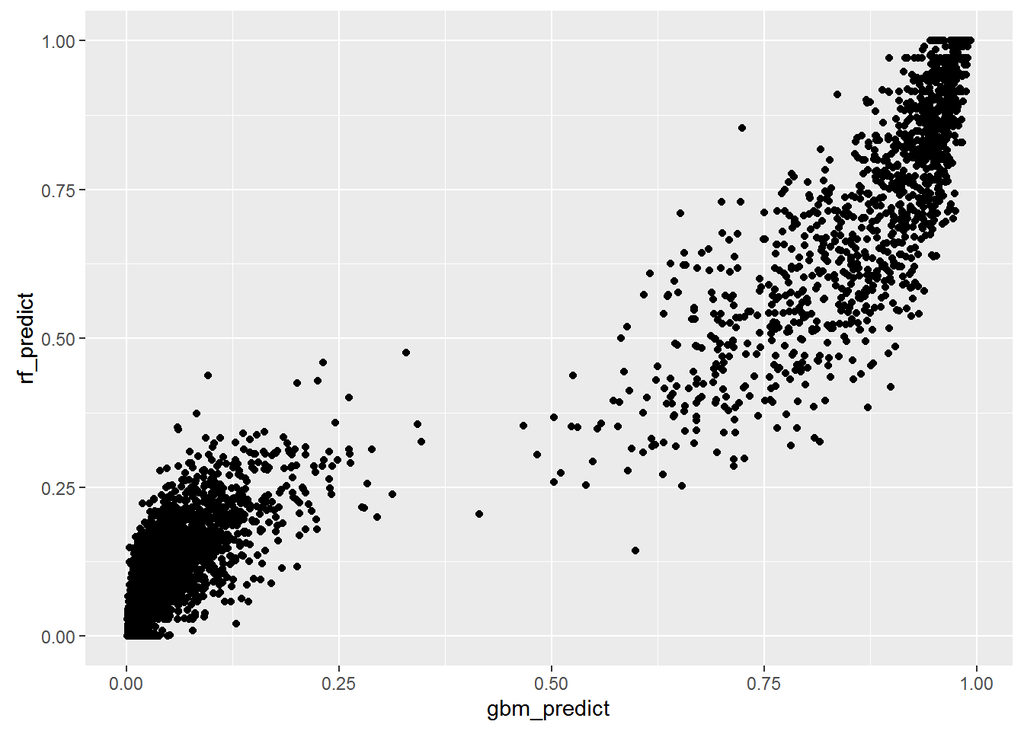

```r
#some plot of the results - deep learning looks very different from the other two methods
data_w_fcast[complete.cases(as.data.frame(h2o_fcast_data)),]%>%ggplot(aes(gbm_predict,rf_predict))+geom_point()
```

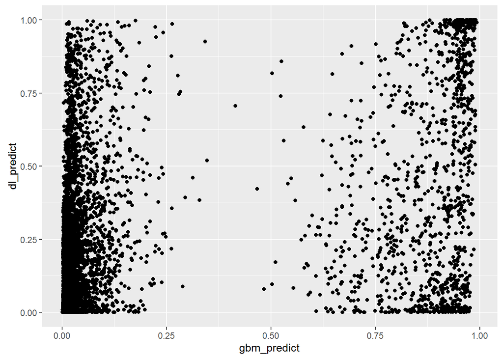

```r
data_w_fcast[complete.cases(as.data.frame(h2o_fcast_data)),]%>%ggplot(aes(gbm_predict,dl_predict))+geom_point()
```

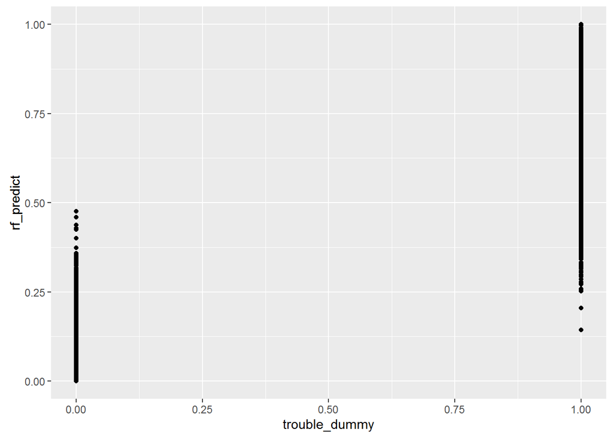

```r
data_w_fcast[complete.cases(as.data.frame(h2o_fcast_data)),]%>%ggplot(aes(trouble_dummy,rf_predict))+geom_point()
```

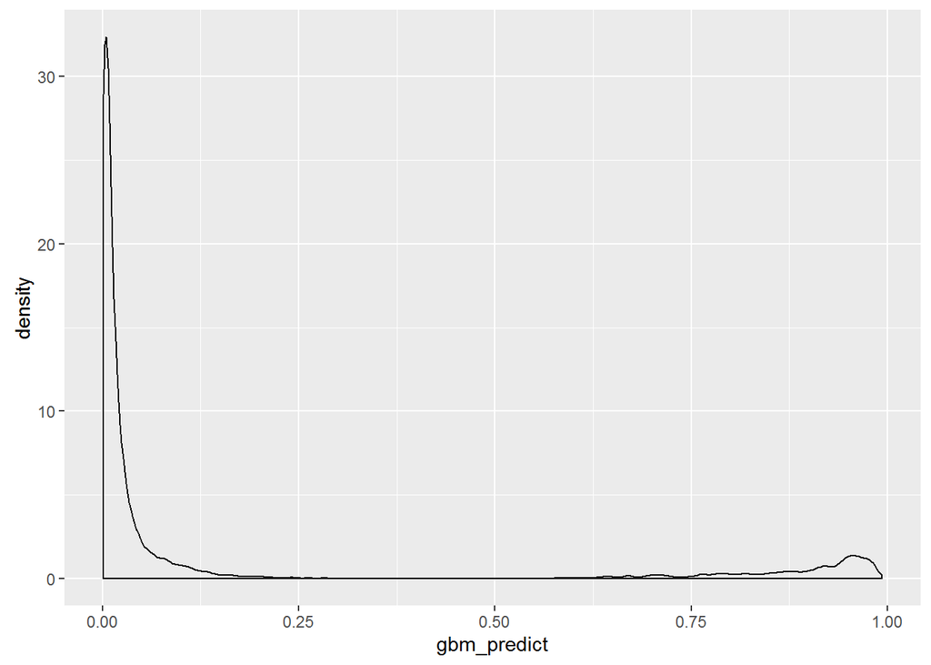

```r
data_w_fcast[complete.cases(as.data.frame(h2o_fcast_data)),]%>%ggplot(aes(gbm_predict))+geom_density()
```

## Let’s see how 2016 looks like in terms of political trouble predicitons. Worst countries are at the top, based on avg_predict (last column), which is the average of the three prediction probabilities (GBM, RF, DL). This is the final test of the model, but can be evaluated only next year :) However, the results look broadly pausible…

```r
panderOptions('round', 4)
panderOptions('keep.trailing.zeros', TRUE)

pred_2016<-data_w_fcast%>%filter(year==2016)%>%mutate(avg_predict=(gbm_predict+rf_predict+dl_predict)/3)%>%arrange(desc(avg_predict))%>%select(-year, -trouble_dummy, -polity_youthr, -gdp_youthr)

pred_2016_nrw<-pred_2016%>%select(country,iso3c,gbm_predict,rf_predict,dl_predict,avg_predict)

#pandoc.table(pred_2016_nrw, split.table= Inf)
#pandoc.table(pred_2016, split.table= Inf)

panderOptions('table.split.table', 300)
pander(pred_2016)
```

| country | iso3c | polity2 | ln_gdp_pc | gdp_pc_grth_lgd | resdummy | youth_r | young_pop_grth | total_pop_grth | gbm_predict | rf_predict | dl_predict | avg_predict |
| --- | --- | --- | --- | --- | --- | --- | --- | --- | --- | --- | --- | --- |
| Congo, the Democratic Republic of the | COD | 16 | 6.306 | 0.0486 | 1 | 0.3023 | 0.0328 | 0.0318 | 0.9652 | 0.9186 | 0.9936 | 0.9591 |
| Central African Republic | CAF | 11 | 6.387 | -0.0783 | 0 | 0.2823 | 0.0183 | 0.02 | 0.9548 | 0.9714 | 0.9285 | 0.9516 |
| Yemen | YEM | 11 | 8.062 | -0.1032 | 0 | 0.3103 | 0.0077 | 0.0241 | 0.9442 | 0.8 | 0.9192 | 0.8878 |
| Libya | LBY | 11 | 7.719 | -0.1431 | 1 | 0.1856 | -0.0012 | 0.0082 | 0.9607 | 0.7143 | 0.9348 | 0.8699 |
| Haiti | HTI | 11 | 7.07 | 0.0215 | 0 | 0.2535 | 0.0056 | 0.0128 | 0.9052 | 0.8337 | 0.7091 | 0.816 |
| Sudan | SDN | 7 | 8.63 | 0.021 | 0 | NA | NA | NA | 0.9906 | 0.9939 | 0.388 | 0.7908 |
| Myanmar | MMR | 8 | 9.085 | 0.0675 | 0 | 0.2037 | 0.0129 | 0.0087 | 0.6842 | 0.6368 | 0.6297 | 0.6502 |
| Palestine, State of | PSE | NA | NA | NA | NA | 0.3059 | 0.02 | 0.0276 | 0.4945 | 0.5731 | 0.7448 | 0.6041 |
| Iraq | IRQ | 14 | 8.012 | 0.024 | 1 | 0.2771 | 0.0289 | 0.0309 | 0.5495 | 0.5478 | 0.5227 | 0.54 |
| Nigeria | NGA | 15 | 8.125 | 0.0215 | 0 | 0.2841 | 0.0268 | 0.0263 | 0.7545 | 0.4892 | 0.3358 | 0.5265 |
| Tuvalu | TUV | NA | 8.112 | 0.0219 | 0 | NA | NA | NA | 0.7211 | 0.7114 | 0.1129 | 0.5151 |
| Marshall Islands | MHL | NA | 8.072 | 0.0109 | 0 | NA | NA | NA | 0.6307 | 0.7114 | 0.1305 | 0.4908 |
| South Sudan | SSD | 11 | 7.47 | NA | 1 | 0.2956 | 0.0341 | 0.0319 | 0.2701 | 0.2857 | 0.8927 | 0.4829 |
| Micronesia, Federated States of | FSM | NA | 7.963 | -0.009 | 0 | 0.3038 | 7e-04 | 0.0048 | 0.186 | 0.3429 | 0.8558 | 0.4615 |
| Timor-Leste | TLS | 18 | 8.562 | -0.0356 | 0 | 0.2865 | 0.0124 | 0.0224 | 0.5402 | 0.6066 | 0.103 | 0.4166 |
| Syrian Arab Republic | SYR | 2 | NA | NA | 1 | 0.2648 | 0.0397 | 0.0033 | 0.5364 | 0.6286 | 0.0143 | 0.3931 |
| Kiribati | KIR | NA | 7.391 | 0.0046 | 0 | 0.2546 | 0.0148 | 0.0176 | 0.2204 | 0.1865 | 0.7474 | 0.3848 |
| Mauritania | MRT | 9 | 7.8 | 0.0285 | 1 | 0.2716 | 0.0249 | 0.0243 | 0.0254 | 0.1332 | 0.9105 | 0.3564 |
| Cote d’Ivoire | CIV | 15 | 7.767 | 0.034 | 0 | 0.2968 | 0.03 | 0.0243 | 0.4117 | 0.354 | 0.2838 | 0.3498 |
| Togo | TGO | 9 | 7.052 | 0.026 | 0 | 0.2817 | 0.0214 | 0.0263 | 0.0591 | 0.2185 | 0.7676 | 0.3484 |
| Saint Lucia | LCA | NA | 9.331 | -0.0023 | 0 | 0.1889 | -0.0047 | 0.0075 | 0.0354 | 0.1733 | 0.7389 | 0.3159 |
| Thailand | THA | 8 | 9.76 | 0.0239 | 0 | 0.1308 | -0.0116 | 0.0028 | 0.4185 | 0.4857 | 0.0421 | 0.3155 |
| Congo | COG | 7 | 8.342 | 0.0115 | 1 | 0.2695 | 0.0277 | 0.0261 | 0.0221 | 0.1314 | 0.7861 | 0.3132 |
| Somalia | SOM | 16 | NA | NA | NA | 0.3152 | 0.0383 | 0.0271 | 0.2659 | 0.6571 | 6e-04 | 0.3079 |
| Eritrea | ERI | 4 | 6.999 | 0.0043 | 0 | 0.2767 | 0.0105 | 0.0237 | 0.473 | 0.2687 | 0.1675 | 0.3031 |
| Sao Tome and Principe | STP | NA | 7.915 | 0.0189 | 0 | 0.2801 | 0.0186 | 0.0213 | 0.0127 | 0.062 | 0.8072 | 0.294 |
| Ghana | GHA | 19 | 8.284 | 0.0463 | 0 | 0.2653 | 0.0118 | 0.0227 | 0.4334 | 0.4013 | 0.0167 | 0.2838 |
| Saint Vincent and the Grenadines | VCT | NA | 9.269 | 0.0104 | 0 | 0.1928 | -0.0072 | 0.0017 | 0.0252 | 0.0876 | 0.7376 | 0.2835 |
| Guinea | GIN | 15 | 6.878 | -0.0034 | 0 | 0.2897 | 0.0275 | 0.0268 | 0.1407 | 0.2011 | 0.481 | 0.2743 |
| Tanzania, United Republic of | TZA | 10 | 7.427 | 0.0456 | 0 | 0.2927 | 0.0286 | 0.0315 | 0.0125 | 0.0453 | 0.7199 | 0.2592 |

[output cut: 177 more lines]

### This table concentrates on just the forecasts, maybe easier to follow

```r
pander(pred_2016_nrw)
```

| country | iso3c | gbm_predict | rf_predict | dl_predict | avg_predict |
| --- | --- | --- | --- | --- | --- |
| Congo, the Democratic Republic of the | COD | 0.9652 | 0.9186 | 0.9936 | 0.9591 |
| Central African Republic | CAF | 0.9548 | 0.9714 | 0.9285 | 0.9516 |
| Yemen | YEM | 0.9442 | 0.8 | 0.9192 | 0.8878 |
| Libya | LBY | 0.9607 | 0.7143 | 0.9348 | 0.8699 |
| Haiti | HTI | 0.9052 | 0.8337 | 0.7091 | 0.816 |
| Sudan | SDN | 0.9906 | 0.9939 | 0.388 | 0.7908 |
| Myanmar | MMR | 0.6842 | 0.6368 | 0.6297 | 0.6502 |
| Palestine, State of | PSE | 0.4945 | 0.5731 | 0.7448 | 0.6041 |
| Iraq | IRQ | 0.5495 | 0.5478 | 0.5227 | 0.54 |
| Nigeria | NGA | 0.7545 | 0.4892 | 0.3358 | 0.5265 |
| Tuvalu | TUV | 0.7211 | 0.7114 | 0.1129 | 0.5151 |
| Marshall Islands | MHL | 0.6307 | 0.7114 | 0.1305 | 0.4908 |
| South Sudan | SSD | 0.2701 | 0.2857 | 0.8927 | 0.4829 |
| Micronesia, Federated States of | FSM | 0.186 | 0.3429 | 0.8558 | 0.4615 |
| Timor-Leste | TLS | 0.5402 | 0.6066 | 0.103 | 0.4166 |
| Syrian Arab Republic | SYR | 0.5364 | 0.6286 | 0.0143 | 0.3931 |
| Kiribati | KIR | 0.2204 | 0.1865 | 0.7474 | 0.3848 |
| Mauritania | MRT | 0.0254 | 0.1332 | 0.9105 | 0.3564 |
| Cote d’Ivoire | CIV | 0.4117 | 0.354 | 0.2838 | 0.3498 |
| Togo | TGO | 0.0591 | 0.2185 | 0.7676 | 0.3484 |
| Saint Lucia | LCA | 0.0354 | 0.1733 | 0.7389 | 0.3159 |
| Thailand | THA | 0.4185 | 0.4857 | 0.0421 | 0.3155 |
| Congo | COG | 0.0221 | 0.1314 | 0.7861 | 0.3132 |
| Somalia | SOM | 0.2659 | 0.6571 | 6e-04 | 0.3079 |
| Eritrea | ERI | 0.473 | 0.2687 | 0.1675 | 0.3031 |
| Sao Tome and Principe | STP | 0.0127 | 0.062 | 0.8072 | 0.294 |
| Ghana | GHA | 0.4334 | 0.4013 | 0.0167 | 0.2838 |
| Saint Vincent and the Grenadines | VCT | 0.0252 | 0.0876 | 0.7376 | 0.2835 |
| Guinea | GIN | 0.1407 | 0.2011 | 0.481 | 0.2743 |
| Tanzania, United Republic of | TZA | 0.0125 | 0.0453 | 0.7199 | 0.2592 |

[output cut: 177 more lines]

## Discussion

### * The prediciton task here is not easy, as countries can have high political risk for years without “trouble” actually happening. We are trying to forecast relatively rare events and weak, probabilistic causal links

### * Clearly, h2o makes forecasts even if some variables are missing - I presume it inputs averages, but I could not find it in the documentation yet

### * Some of the forecasts with incomplete data look quite good, that is why I left these in (PSE is for Palestinian Authority for example, SOM is for Somalia, both have only partial data, but political instability is plausible)

### * There is a risk that there was some covert overfitting, despite the fact that cross validation and early stopping was used: this is partly time series data, and countries tend to be similar from one year to another (year variable was not included in the estimates of course)

### * I was surprised by the fact how different Deep Learning results were from the other two methods (also a lot lower AUC). I could not figure out why that is the case - overfitting in the case of the other two methods could be an explanation, but this is just a guess and I will need to investigate further

### * With all the caveats, I like the results: countries with low “trouble” probabilities are usually fare good on other political stability rankings as well, and vice versa

### * An interesting case is Singapore, where despite being rich, the final model is forecasting a larger probability of political trouble than in other rich countries - it seems that it learned the importance of the polity2 (democracy) variable. And this is unlikely to be a case of secretly overfitting, as there was no political trouble in Singapore in the past 50 years (and very little in similar rich countries)

### * On the other hand, the fact that most of the top countries in terms of forecasted political instability had a recent history of political instability point to possible overfitting

### * Also, in some cases you can observe a jump in the predicted probability once a “trouble” event occured, at least in the case of RF and GBM - again a sign of possible overfitting

### * Looking at the ROC curve in h2o, training metric is suspiciously high for GBM, DL and RF look more reasonable

### * I presume that h2o randomly scambles data to create the cross-validation bins. In this case it would be better to take cases sequentially, then the estimation would take different countries than the cross validation, but I only know how to implement that manually.

And finally we shut down h2o:

```r
#bye! :)
h2o.shutdown()
```

```
## Are you sure you want to shutdown the H2O instance running at http://127.0.0.1:54321/ (Y/N)?
```

## Closing comments:

### * I spent too much time with data munging and too little with modeling - as we learned at class :)

### * The most valuable part of this work probably was that it gathered a dataset and put it in a usable format - this will make further estimations and discovery possible

### * This is a work in progress, and despite the overtime, I could not make it as nice as I would have liked - sorry about the messy outcome…

### * But it was fun and I learned a lot :) in the hard way :)

### * Also, some of the results are interesting, as dicussed above, and I would like to investigate them further, especially the possible case of overfitting